# Report Italian Vaccines

## 1 Total non-vaccinated Population

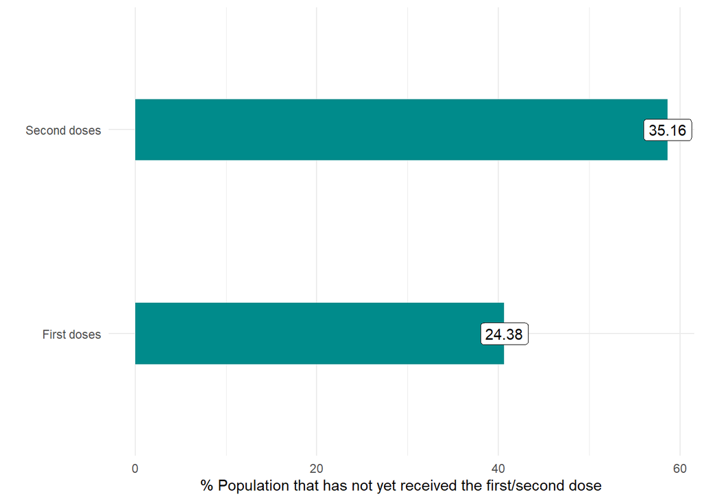

## 2 Non-vaccinated population by age range

### 2.1 Non-vaccinated population by age range - First Doses

The plot shows percentage/millions of people that have not yet received the first vaccine shot, by age range:

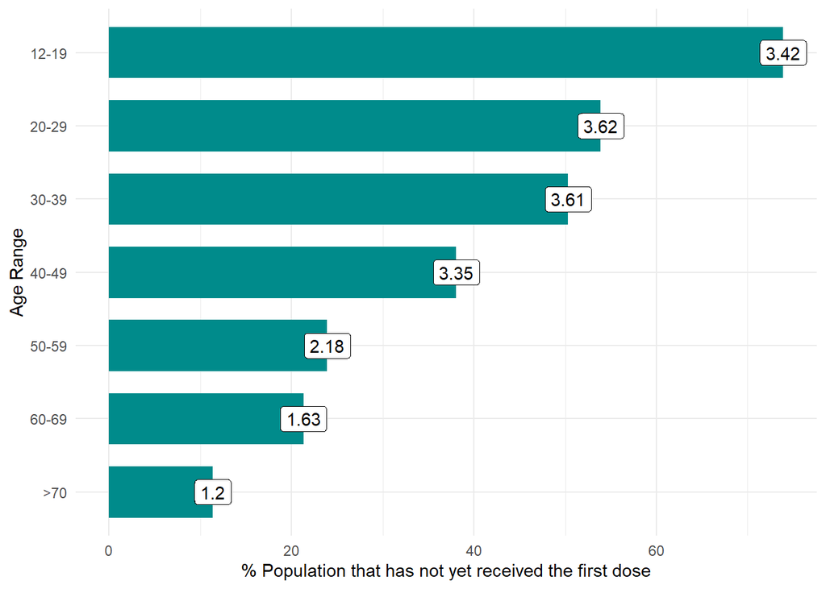

The plot shows the trend of the percentage of population who has not yet received the first vaccine shot, by age range:

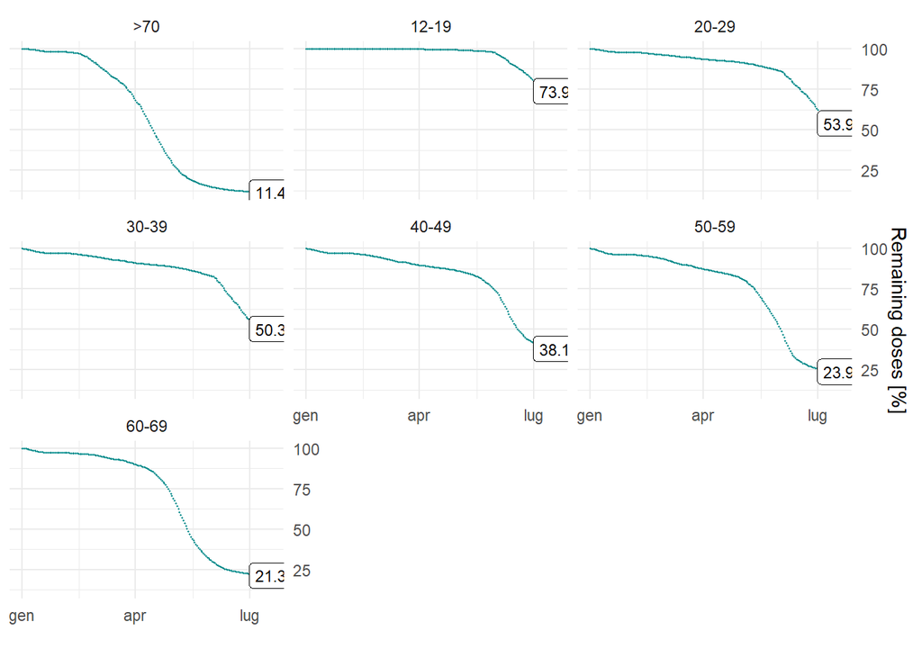

### 2.2 Non-vaccinated population by age range - Second Doses

The plot shows percentage/millions of people that have not yet received the second vaccine shot, by age range:

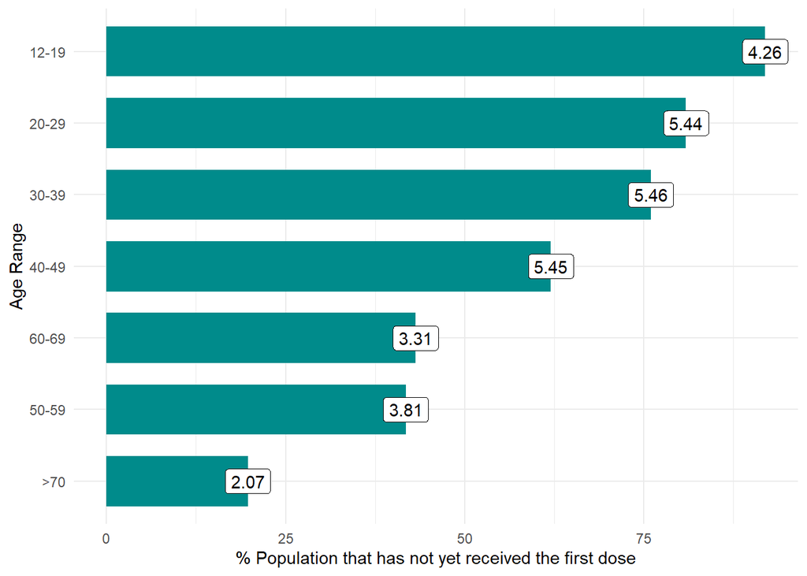

The plot shows the trend of the percentage of population who has not yet received the second vaccine shot, by age range:

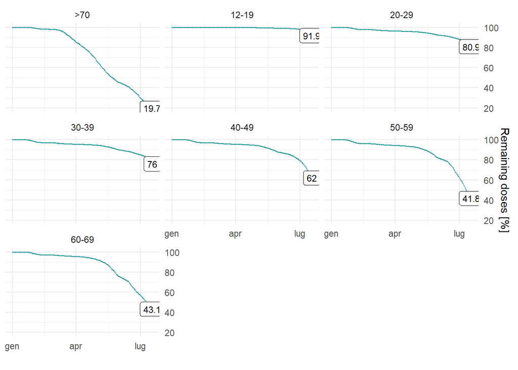

## Non-vaccinated population by region

### 3.1 Non-vaccinated population by region - First Doses

The plot shows percentage/millions of people that have not yet received the first vaccine shot, by region:

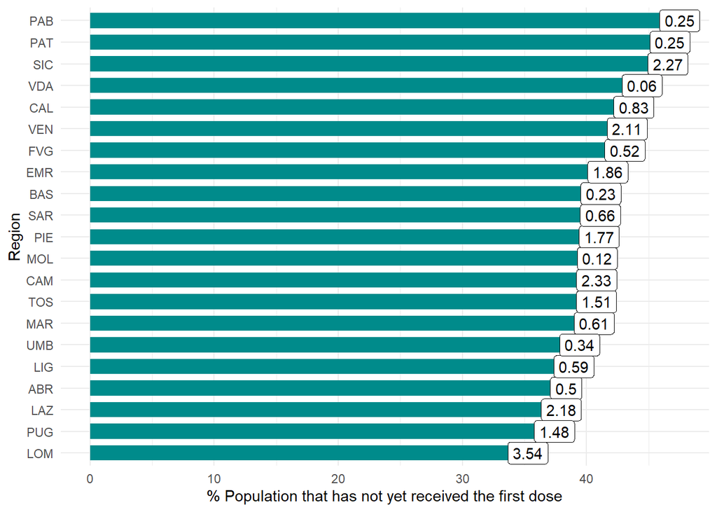

The final date is an ideal scenario that tells when the first dose vaccination will be completed, by region, assuming the most recent weekly average first dose vaccination rate to be constant:

| region | final_date |
| --- | --- |
| BAS | 2021-11-22 |
| PUG | 2021-12-22 |
| TOS | 2021-12-31 |
| ABR | 2022-01-16 |
| LIG | 2022-01-18 |
| VDA | 2022-01-29 |
| PAT | 2022-02-12 |
| SAR | 2022-02-12 |
| LOM | 2022-04-07 |
| PAB | 2022-04-16 |
| EMR | 2022-04-30 |
| SIC | 2022-05-04 |
| CAL | 2022-05-18 |
| MAR | 2022-07-21 |
| LAZ | 2022-07-26 |
| PIE | 2022-08-23 |
| VEN | 2022-09-02 |
| FVG | 2022-09-30 |
| MOL | 2022-10-15 |
| CAM | 2022-10-24 |
| UMB | 2022-11-22 |

### 3.2 Non-vaccinated population by region - Second Doses

The plot shows percentage/millions of people that have not yet received the second vaccine shot, by region:

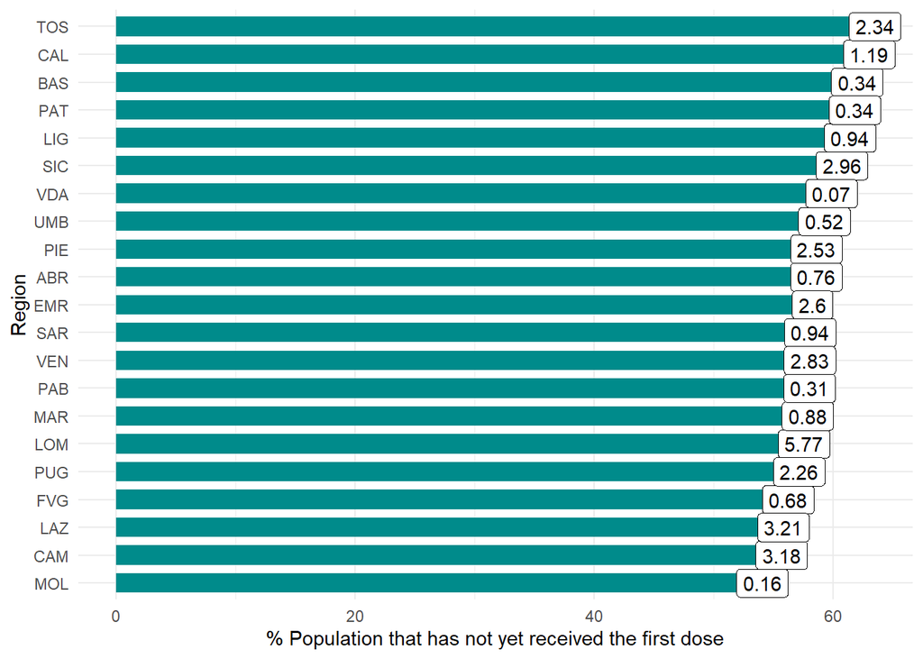

The final date is an ideal scenario that tells when the second dose vaccination will be completed, by region, assuming the most recent weekly average second dose vaccination rate to be constant:

| region | final_date |
| --- | --- |
| LOM | 2021-09-15 |
| CAM | 2021-09-17 |
| ABR | 2021-09-18 |
| MOL | 2021-09-18 |
| MAR | 2021-09-22 |
| EMR | 2021-09-24 |
| PIE | 2021-09-24 |
| SIC | 2021-09-28 |
| VEN | 2021-09-28 |
| UMB | 2021-10-03 |
| CAL | 2021-10-05 |
| BAS | 2021-10-06 |
| LAZ | 2021-10-06 |
| PUG | 2021-10-08 |
| SAR | 2021-10-10 |
| FVG | 2021-10-14 |
| VDA | 2021-10-18 |
| PAB | 2021-11-06 |
| TOS | 2021-11-08 |
| LIG | 2021-11-22 |
| PAT | 2022-01-21 |